# Loading and preprocessing the data

### Loading and preprocessing the data

Download the zip file and unzip it

```r
url <- "http://d396qusza40orc.cloudfront.net/repdata%2Fdata%2Factivity.zip"
download.file(url, "repdata-data-activity.zip", mode="wb")
unzip("repdata-data-activity.zip")
```

Load the data from the CSV

```r
activity <- as.data.frame(read.csv("activity.csv"))
```

### What is mean total number of steps taken per day?

Calculate the total number of steps taken per day (totalsteps is an array of integers)

```r
totalsteps <- by(activity$steps,activity$date,FUN=sum,
                 na.rm=TRUE)
```

Make a histogram of the total number of steps taken each day

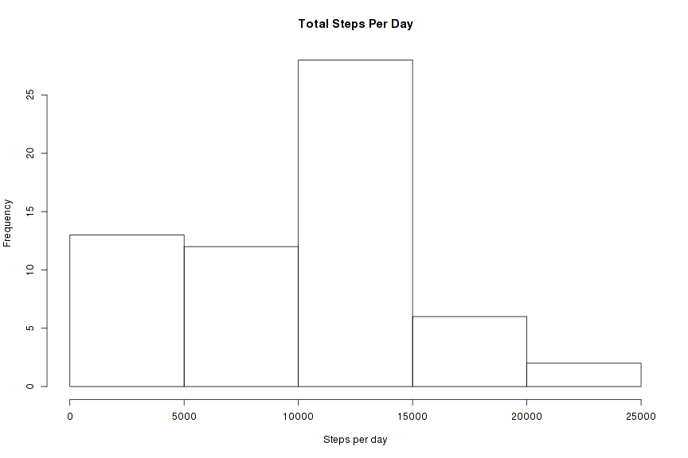

```r
hist(totalsteps,
     main="Total Steps Per Day",
     xlab="Steps per day")
```

Calculate and report the mean of the total number of steps taken per day

```r
cat("Mean total steps taken per day: ",
    mean(totalsteps))
```

```
## Mean total steps taken per day:  9354.23
```

Calculate and report the median of the total number of steps taken per day

```r
cat("Median total steps taken per day: ",
    median(totalsteps))
```

```
## Median total steps taken per day:  10395
```

### What is the average daily activity pattern?

Calculate the mean of steps taken per interval (intervals is an array of integers)

```r
avgsteps <- as.numeric(by(activity$steps,activity$interval,
                FUN=mean, na.rm=TRUE))
```

Get the list of interval numbers

```r
intervalnumber <- as.numeric(unique(activity$interval))
```

Create a data frame in which each interval number is paired with its average number of steps

```r
df <- as.data.frame(avgsteps)
df <- cbind(df, intervalnumber)
```

Make a time series plot of the 5-minute interval (x-axis) and the average number of steps taken, averaged across all days (y-axis)

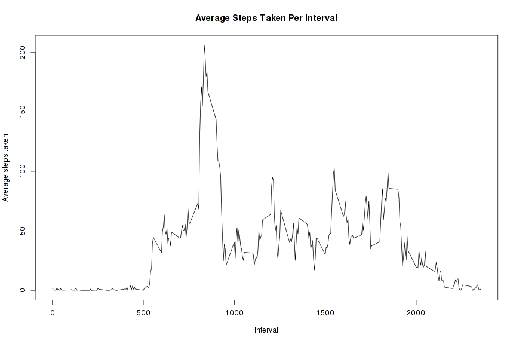

```r
plot(avgsteps ~ intervalnumber, df, type="l",
        main="Average Steps Taken Per Interval",
        xlab="Interval",
        ylab="Average steps taken")
```

Max value is intervals[104] - 835, 206.1698

```r
which.max(df$avgsteps)
```

```
## [1] 104
```

Print that result

```r
cat("5-minute interval with maximum number of steps on average: \n interval",
    df$intervalnumber[which.max(df$avgsteps)], "\n which has an average of",
    df$avgsteps[which.max(df$avgsteps)], "steps across all days.")
```

```
## 5-minute interval with maximum number of steps on average:
##  interval 835
##  which has an average of 206.1698 steps across all days.
```

### Imputing missing values

Calculate and report the total number of missing values in the dataset (i.e. the total number of rows with NAs)

```r
cat(sum(is.na(activity)),
    "rows in the data frame contain NAs.")
```

```
## 2304 rows in the data frame contain NAs.
```

Replace each NA with the mean number of steps for that 5-minute interval

```r
activity2 <- activity
activity2$steps <- ave(activity2$steps,activity2$interval,FUN=function(x){
        mm <- mean(x,na.rm=TRUE)
        ifelse(is.na(x),mm,x)
})
```

Calculate the total number of steps taken per day (totalsteps is an array of integers)

```r
totalsteps2 <- by(activity2$steps,activity2$date,FUN=sum,
                 na.rm=TRUE)
```

Make a histogram of the total number of steps taken each day

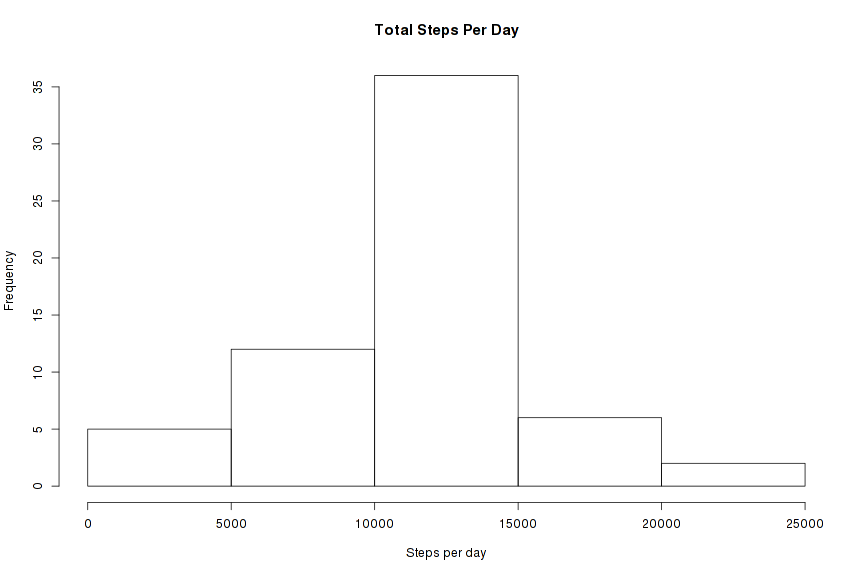

```r
hist(totalsteps2,
     main="Total Steps Per Day",
     xlab="Steps per day")
```

Calculate and report the mean of the total number of steps taken per day

```r
cat("Mean total steps taken per day: ",
    mean(totalsteps2))
```

```
## Mean total steps taken per day:  10766.19
```

Calculate and report the median of the total number of steps taken per day

```r
cat("Median total steps taken per day: ",
    median(totalsteps2))
```

```
## Median total steps taken per day:  10766.19
```

### What is the average daily activity pattern?

Calculate the mean of steps taken per interval (intervals is an array of integers)

```r
avgsteps2 <- as.numeric(by(activity2$steps,activity2$interval,
                          FUN=mean, na.rm=TRUE))
```

Get the list of interval numbers

```r
intervalnumber2 <- as.numeric(unique(activity2$interval))
```

Create a data frame in which each interval number is paired with its average number of steps

```r
df2 <- as.data.frame(avgsteps2)
df2 <- cbind(df2, intervalnumber2)
```

Make a time series plot of the 5-minute interval (x-axis) and the average number of steps taken, averaged across all days (y-axis)

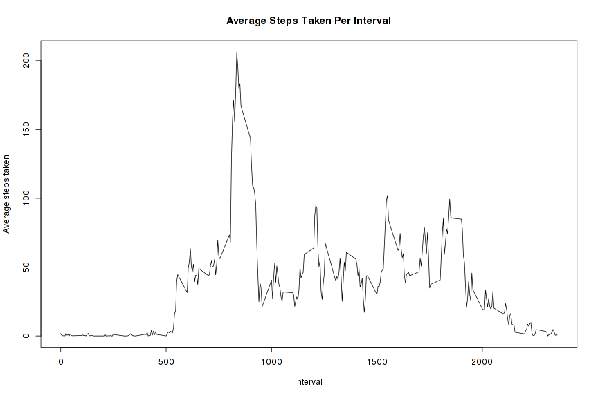

```r
plot(avgsteps2 ~ intervalnumber2, df2, type="l",
     main="Average Steps Taken Per Interval",
     xlab="Interval",
     ylab="Average steps taken")
```

Max value is intervals[104] - 835, 206.1698

```r
which.max(df$avgsteps)
```

```
## [1] 104
```

Print that result

```r
cat("5-minute interval with maximum number of steps on average: \n interval",
    df2$intervalnumber2[which.max(df2$avgsteps2)], "\n which has an average of",
    df2$avgsteps2[which.max(df2$avgsteps2)], "steps across all days.")
```

```
## 5-minute interval with maximum number of steps on average:
##  interval 835
##  which has an average of 206.1698 steps across all days.
```

### Are there differences in activity patterns

### between weekdays and weekends?

Create a new factor variable in the dataset with two levels – “weekday” and “weekend” indicating whether a given date is a weekday or weekend day.

Create a new data frame

```r
activity3 <- activity2
```

Add a column with numbered days of the week

```r
activity3$daytype <- as.POSIXlt(activity3$date)$wday
```

Replace days 6 and 0 (Sat & Sun) with the factor variable “weekend”

```r
activity3$daytype[activity3$daytype == 0 | activity3$daytype == 6] <- "weekend"
```

Replace days days that aren't weekends with the factor variable “weekday”

```r
activity3$daytype[activity3$daytype != "weekend"] <- "weekday"
```

Make a panel plot containing a time series plot (i.e. type = “l”) of the 5-minute interval (x-axis) and the average number of steps taken, averaged across all weekday days (y-axis).

Make a data frame for just weekdays

```r
weekdays <- activity3[activity3$daytype=="weekday",]
```

Find the average number of steps for each interval across all weekdays

```r
avgsteps_wd <- as.numeric(by(weekdays$steps,weekdays$interval,
                           FUN=mean, na.rm=TRUE))
```

Get the list of interval numbers

```r
intervalnumber_wd <- as.numeric(unique(weekdays$interval))
```

Create a data frame in which each interval number is paired with its average number of steps

```r
df_wd <- as.data.frame(avgsteps_wd)
df_wd <- cbind(df_wd, intervalnumber_wd)
```

```r
days.par <- par(mfrow=c(1, 2))
```

First make the plot for weekdays

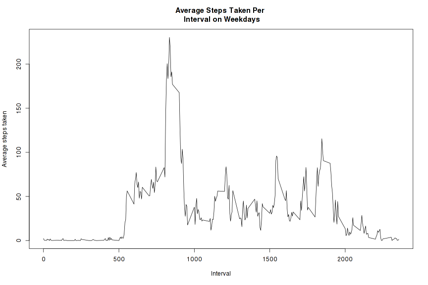

```r
plot(avgsteps_wd ~ intervalnumber_wd, df_wd, type="l",
     main="Average Steps Taken Per \n Interval on Weekdays",
     xlab="Interval",
     ylab="Average steps taken")
```

And then add an equivalent plot for all weekend days

Make a data frame for just weekends

```r
weekends <- activity3[activity3$daytype=="weekend",]
```

```r
avgsteps_we <- as.numeric(by(weekends$steps,weekends$interval,
                             FUN=mean, na.rm=TRUE))
```

Get the list of interval numbers

```r
intervalnumber_we <-
as.numeric(unique(weekends$interval))
```

Create a data frame in which each interval number is paired with its average number of steps

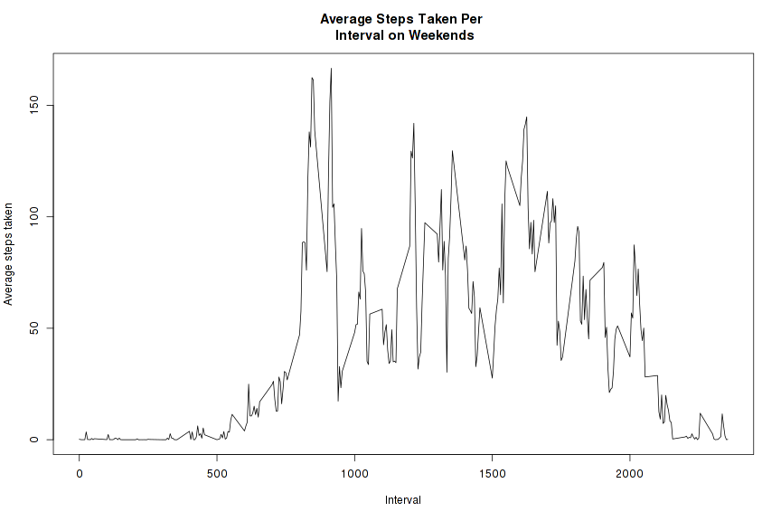

```r
df_we <- as.data.frame(avgsteps_we)
df_we <- cbind(df_we, intervalnumber_we)

plot(avgsteps_we ~ intervalnumber_we, df_we, type="l",
     main="Average Steps Taken Per \n Interval on Weekends",
     xlab="Interval",
     ylab="Average steps taken")
```